# Stock Market Valuation by Shawn P Emhe II

In *Irrational Exhuberance*, Robert Shiller compiled over 100 years of data to demonstrate how market dynamics create cycles in which the stock market prices become disconnected with valuations. One criticism[^1] of his work is that prices are set by the market, not by valuations, and because of this no one can say when the market is “overvalued” or “undervalued.” I intend to use the dataset to explore the link between value and price.

# Data Wrangling

The data is already in tidy format, but still requires some wrangling prior to exploration.

```
## 'data.frame':    1769 obs. of  11 variables:
##  $ Date        : num  1871 1871 1871 1871 1871 ...
##  $ Price       : num  4.44 4.5 4.61 4.74 4.86 4.82 4.73 4.79 4.84 4.59 ...
##  $ Dividend    : num  0.26 0.26 0.26 0.26 0.26 0.26 0.26 0.26 0.26 0.26 ...
##  $ Earnings    : num  0.4 0.4 0.4 0.4 0.4 0.4 0.4 0.4 0.4 0.4 ...
##  $ CPI         : num  12.5 12.8 13 12.6 12.3 ...
##  $ DateFraction: num  1871 1871 1871 1871 1871 ...
##  $ GS10        : num  5.32 5.32 5.33 5.33 5.33 5.34 5.34 5.34 5.35 5.35 ...
##  $ RealPrice   : num  89 87.6 88.4 94.3 99 ...
##  $ RealDividend: num  5.21 5.06 4.99 5.17 5.3 5.38 5.38 5.46 5.34 5.25 ...
##  $ RealEarnings: num  8.02 7.78 7.67 7.96 8.15 8.27 8.27 8.41 8.21 8.08 ...
##  $ CAPE        : num  NA NA NA NA NA NA NA NA NA NA ...
```

The `str` command shows that there are two date fields.

1. Date: 1871.01, 1871.02, 1871.03 …
2. DateFraction: 1871.04, 1871.13, 1871.21 …

Both use a YYYY.MM format, with the first numbering the months 01 through 12 and the second representing months as a fraction of the year. I reviewed the background information[^2] on the dataset and the original excel file. The most logical explanation I could find was that the second format was created for use as the X-axis for the charts in the excel file. The first format was likely an output of another program or data source and is not a format interpretable by excel.

I converted the values into an R friendly Date format and dropped the DateFraction column.

The dataset contains the 10-Year Treasury Constant Maturity Rate labeled as GS10. The rates are in percentage form, most likely to make them easier to plot alongside the other features in the original excel file. I converted them to decimal form to prepare for analysis.

## Feature Extraction

As an additional preparation step I created several new factors from the data:

1. Inflation
   - Measured as the annual % change in CPI
   - As a categorical value: Rising or Falling
2. Momentum
   - % Change in price over the past year
   - As a categorical value: Rising or Falling
3. Forward Returns
   - Measured as a % over 1, 3, 5 and 10 years
   - Categorical value representing if the 1 year “Outlook” was Bullish or Bearish

Inflation was captured out of curiosity of its affect on future returns. Momentum was measured because studies have shown that price advances and declines can persist.[^3] I am interested to see if it will make a good complement to value in predicting returns.

I created a `pct_change` function to extract the above features from the price and CPI columns. I also created a function to shift the results of the `pct_change` for building the future returns values.

Furthermore, I used categorical variations of the inflation and momentum to assist in exploring positive and negative conditions of each.

# Univariate Plots Section

```
## 'data.frame':    1769 obs. of  19 variables:
##  $ Date          : Date, format: "1871-01-01" "1871-02-01" ...
##  $ Price         : num  4.44 4.5 4.61 4.74 4.86 4.82 4.73 4.79 4.84 4.59 ...
##  $ Dividend      : num  0.26 0.26 0.26 0.26 0.26 0.26 0.26 0.26 0.26 0.26 ...
##  $ Earnings      : num  0.4 0.4 0.4 0.4 0.4 0.4 0.4 0.4 0.4 0.4 ...
##  $ CPI           : num  12.5 12.8 13 12.6 12.3 ...
##  $ GS10          : num  0.0532 0.0532 0.0533 0.0533 0.0533 0.0534 0.0534 0.0534 0.0535 0.0535 ...
##  $ RealPrice     : num  89 87.6 88.4 94.3 99 ...
##  $ RealDividend  : num  5.21 5.06 4.99 5.17 5.3 5.38 5.38 5.46 5.34 5.25 ...
##  $ RealEarnings  : num  8.02 7.78 7.67 7.96 8.15 8.27 8.27 8.41 8.21 8.08 ...
##  $ CAPE          : num  NA NA NA NA NA NA NA NA NA NA ...
##  $ Momentum      : num  NA NA NA NA NA NA NA NA NA NA ...
##  $ CPIChange     : num  NA NA NA NA NA NA NA NA NA NA ...
##  $ Growth        : Factor w/ 2 levels "Expansion","Recession": NA NA NA NA NA NA NA NA NA NA ...
##  $ Inflation     : Factor w/ 2 levels "Deflation","Inflation": NA NA NA NA NA NA NA NA NA NA ...
##  $ Fwd1yrReturns : num  0.0946 0.0844 0.0933 0.0928 0.0658 ...
##  $ Fwd3yrReturns : num  0.0495 0.0667 0.026 -0.0295 -0.0782 ...
##  $ Fwd5yrReturns : num  0.0045 0.00444 -0.02169 -0.08439 -0.13992 ...
##  $ Fwd10yrReturns: num  0.394 0.371 0.354 0.312 0.337 ...
##  $ Outlook       : Factor w/ 2 levels "Bearish","Bullish": 2 2 2 2 2 2 2 2 2 2 ...
```

```
##       Date                Price            Dividend         Earnings
##  Min.   :1871-01-01   Min.   :   2.73   Min.   : 0.180   Min.   :  0.160
##  1st Qu.:1907-11-01   1st Qu.:   7.74   1st Qu.: 0.410   1st Qu.:  0.540
##  Median :1944-09-01   Median :  16.42   Median : 0.830   Median :  1.325
##  Mean   :1944-08-31   Mean   : 259.74   Mean   : 5.637   Mean   : 12.810
##  3rd Qu.:1981-07-01   3rd Qu.: 122.90   3rd Qu.: 6.370   3rd Qu.: 13.607
##  Max.   :2018-05-01   Max.   :2789.80   Max.   :50.000   Max.   :109.880
##                                         NA's   :2        NA's   :5
##       CPI              GS10           RealPrice        RealDividend
##  Min.   :  6.28   Min.   :0.01500   Min.   :  67.67   Min.   : 4.99
##  1st Qu.: 10.10   1st Qu.:0.03290   1st Qu.: 170.13   1st Qu.: 8.53
##  Median : 18.20   Median :0.03860   Median : 253.23   Median :12.73
##  Mean   : 57.84   Mean   :0.04569   Mean   : 509.86   Mean   :15.17
##  3rd Qu.: 91.60   3rd Qu.:0.05220   3rd Qu.: 613.87   3rd Qu.:19.27
##  Max.   :249.98   Max.   :0.15320   Max.   :2813.54   Max.   :50.08
##                                                       NA's   :2
##   RealEarnings         CAPE          Momentum          CPIChange
##  Min.   :  4.19   Min.   : 4.78   Min.   :-0.65609   Min.   :-0.19700
##  1st Qu.: 12.66   1st Qu.:11.79   1st Qu.:-0.06067   1st Qu.: 0.00000
##  Median : 20.45   Median :16.17   Median : 0.06691   Median : 0.02264
##  Mean   : 29.87   Mean   :16.86   Mean   : 0.06119   Mean   : 0.02236
##  3rd Qu.: 39.34   3rd Qu.:20.47   3rd Qu.: 0.18493   3rd Qu.: 0.04615
##  Max.   :111.42   Max.   :44.20   Max.   : 1.24152   Max.   : 0.23669
##  NA's   :5        NA's   :120     NA's   :12         NA's   :12
##        Growth         Inflation    Fwd1yrReturns      Fwd3yrReturns
##  Expansion:1113   Deflation: 474   Min.   :-0.65609   Min.   :-0.82409
##  Recession: 644   Inflation:1283   1st Qu.:-0.06067   1st Qu.:-0.05511
##  NA's     :  12   NA's     :  12   Median : 0.06691   Median : 0.16223
##                                    Mean   : 0.06119   Mean   : 0.18797
##                                    3rd Qu.: 0.18493   3rd Qu.: 0.40225
##                                    Max.   : 1.24152   Max.   : 1.38523
##                                    NA's   :12         NA's   :36
##  Fwd5yrReturns      Fwd10yrReturns        Outlook
##  Min.   :-0.71629   Min.   :-0.61661   Bearish: 644
##  1st Qu.:-0.05574   1st Qu.: 0.07159   Bullish:1113
##  Median : 0.24275   Median : 0.49322   NA's   :  12
##  Mean   : 0.33082   Mean   : 0.72440
##  3rd Qu.: 0.64044   3rd Qu.: 1.29522
##  Max.   : 2.38378   Max.   : 3.65442
##  NA's   :60         NA's   :120
```

### Price

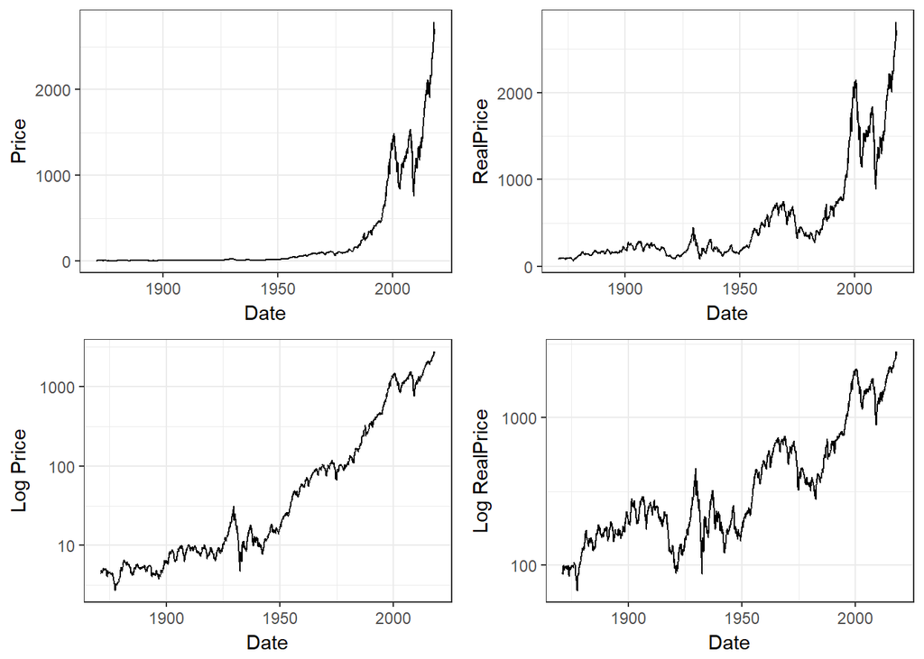

Because the value of price is measured over time it is best plotted as a time series. The scale of the first plot makes it difficult to compare the data starting in the late 1800s to more recent years. The dataset already contains a transformed version in the form of RealPrice, which has been adjusted for inflation. Taking the log10 of the prices makes them even more readable, which is a natural transformation because price growth is geometric. The final inflation adjusted and log transformed graph makes it easy to compare the growth and recessions over the entire history of the dataset.

### Dividends and Earnings

Logically, the dividends and earnings should benefit from the same transformations.

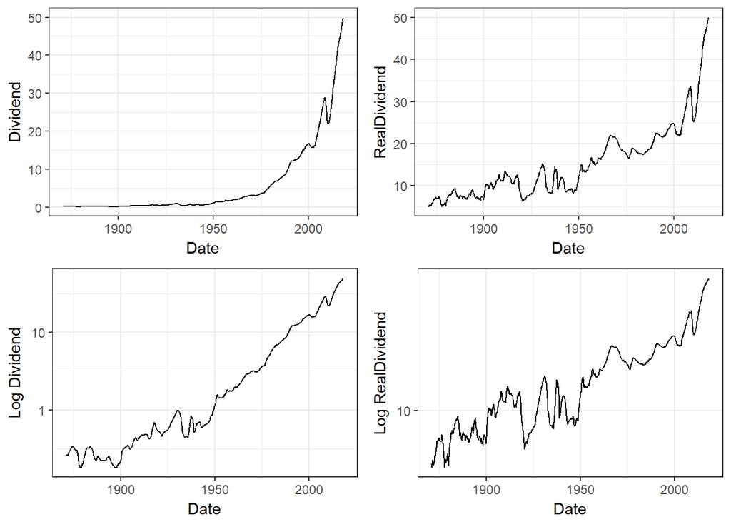

Dividends show the same steady growth over time as price. But the second half of the data appears to have much lower variance than the first half. I wonder if this is due to the decision to start taxing dividends in 1954.[^4]

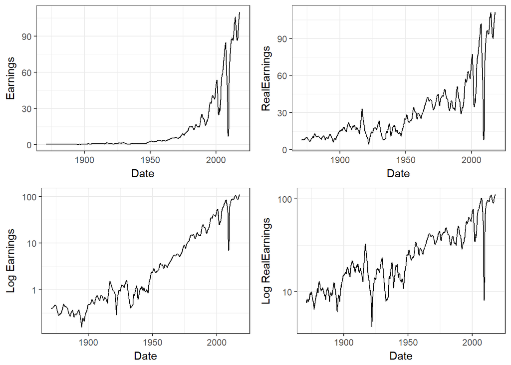

An interesting feature of the earnings data are the two significant dips that occurring during the Great Depression and Great Recession of the 1930’s and 2008. Earnings appear to have been impacted even harder than stock prices.

### Interest Rates

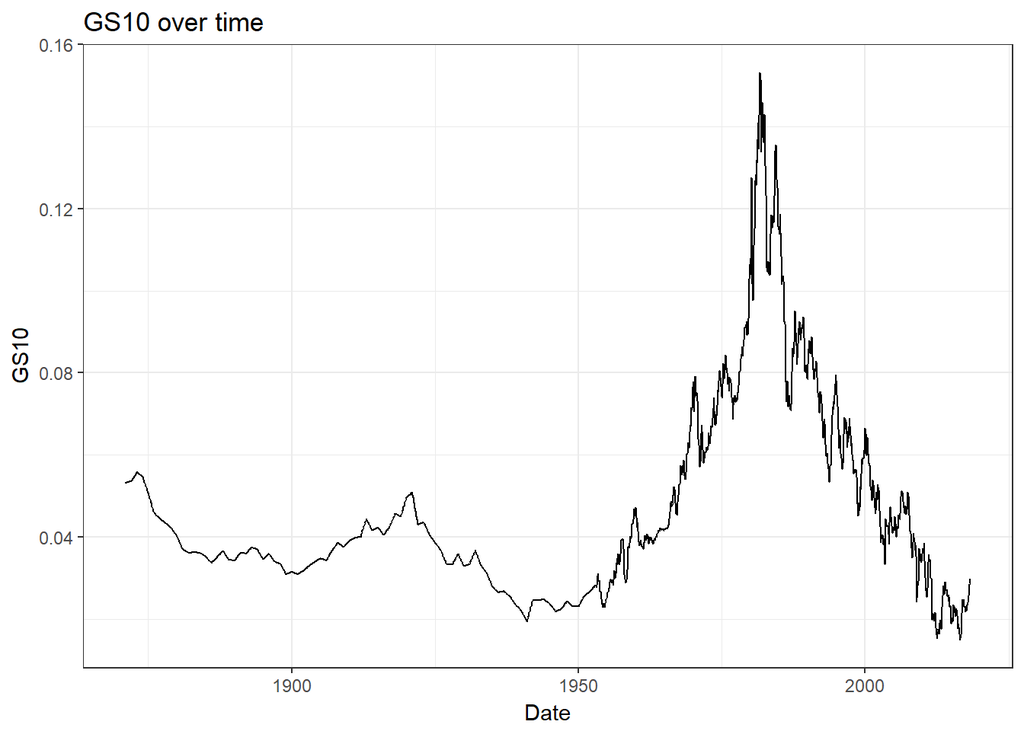

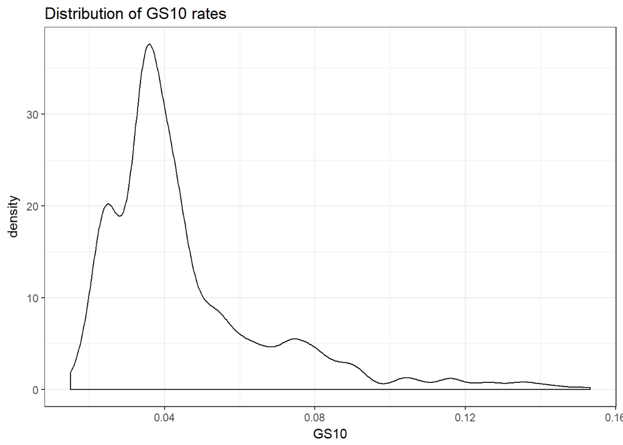

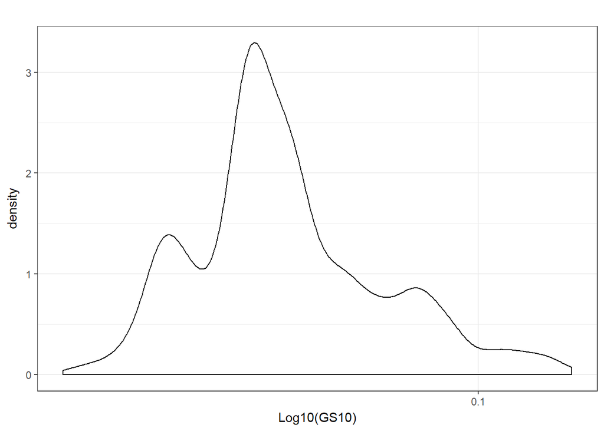

```
##    Min. 1st Qu.  Median    Mean 3rd Qu.    Max.
## 0.01500 0.03290 0.03860 0.04569 0.05220 0.15320
```

### CAPE

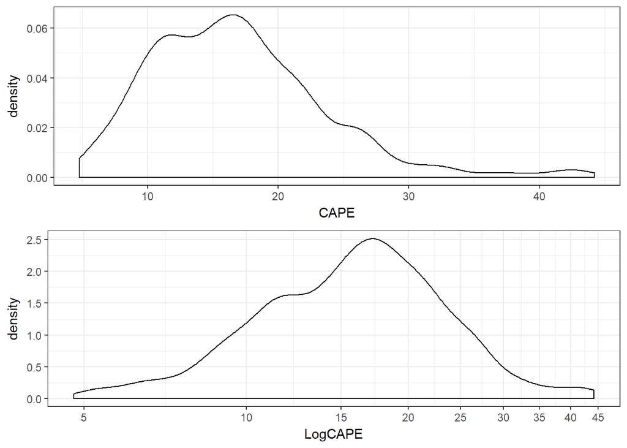

CAPE, the Cyclically Adjusted Price to Earnings Ratio, is the heart of the dataset. Robert Shiller created the ratio to smooth for inflation and business cycle affects by dividing the inflation adjusted price by 10 year average of the earnings.

Transforming to log scale makes it easier to see an important characteristic. The tails of the distribution represent the cheapest and most expensive readings for the market. However, the normal scale of the x axis diminishes the fact that changes in the lower end represent proportionately larger percentage differences in price per earnings. For example, the difference between a value of 4 and 5 means paying 25% more for earnings, whereas 40 to 41 is only and increase of 2.5%. The log scale balances the emphasis placed on the rare occurrence of valuations at both ends of the spectrum.

### Momentum

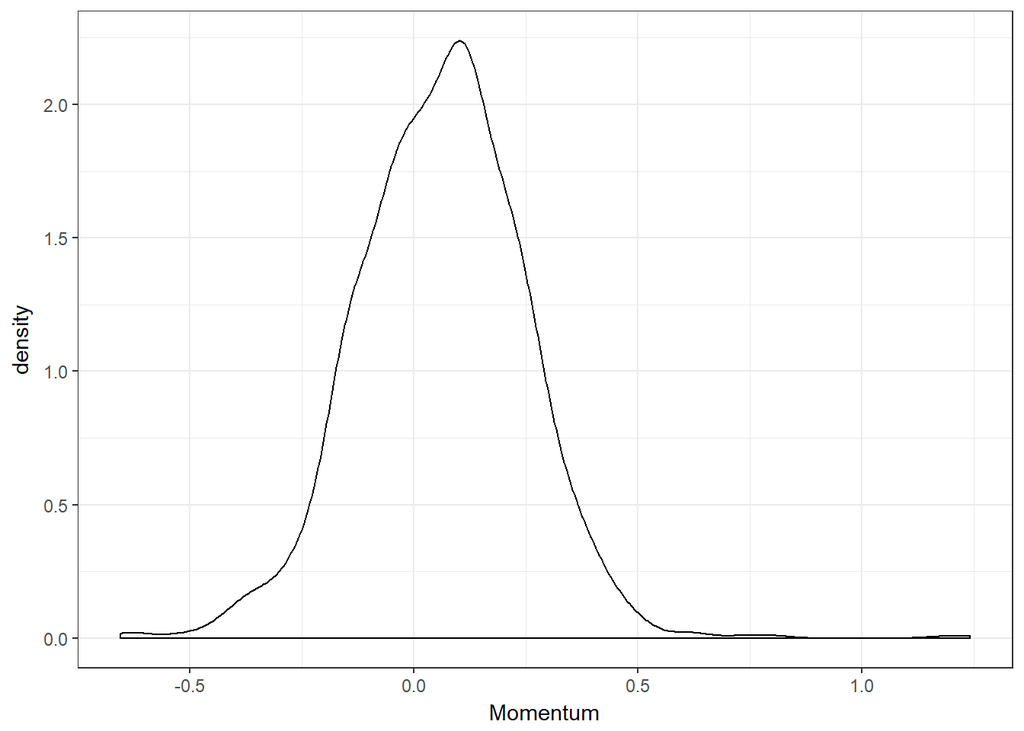

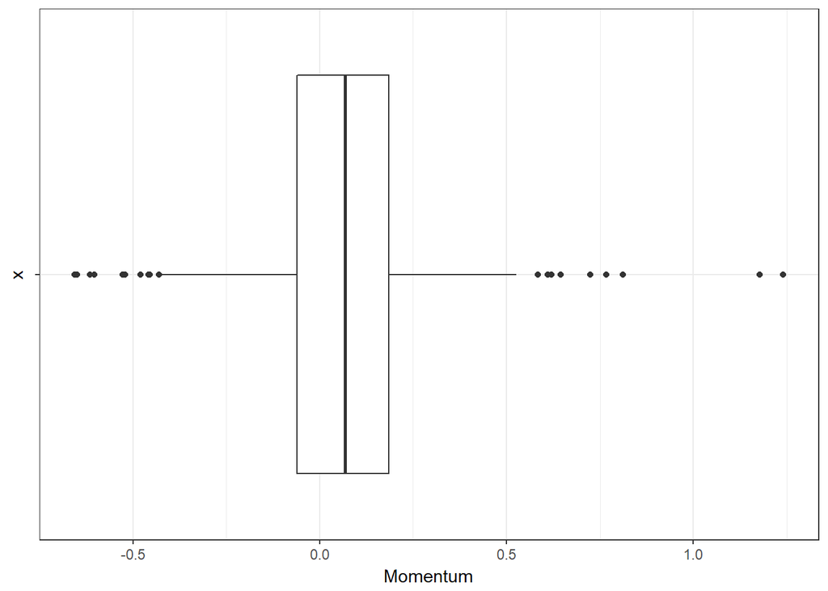

```
##     Min.  1st Qu.   Median     Mean  3rd Qu.     Max.     NA's
## -0.65609 -0.06067  0.06691  0.06119  0.18493  1.24152       12
```

The Momentum distribution has long tails, with outlier years returning over 100% and losing more than 50%. The boxplot makes these extreme occurrences easy to see. The mean annual return was 6.12%.

### Inflation

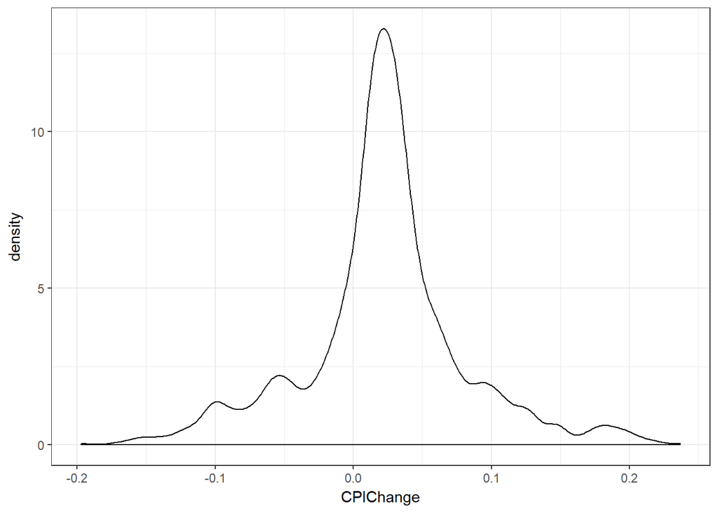

```
##     Min.  1st Qu.   Median     Mean  3rd Qu.     Max.     NA's
## -0.19700  0.00000  0.02264  0.02236  0.04615  0.23669       12
```

The distribution of CPIChange shows very high kurtosis, with a mean of 2.24%. This aligns with the Fed’s target, while the tails show just how far inflation and deflation can go when they get out of hand.

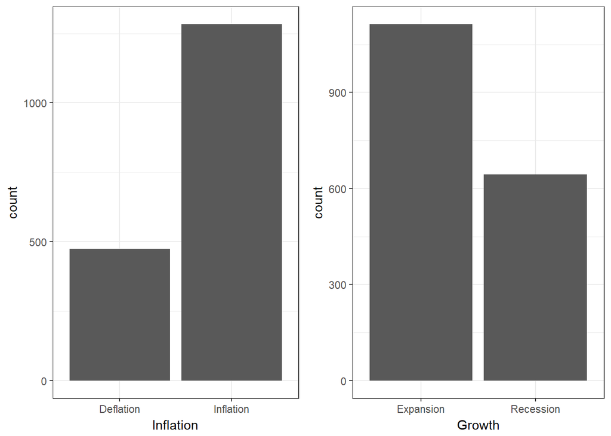

The bar charts show that the US has spent most of period in a state of rising inflation and growth.

### Forward Returns

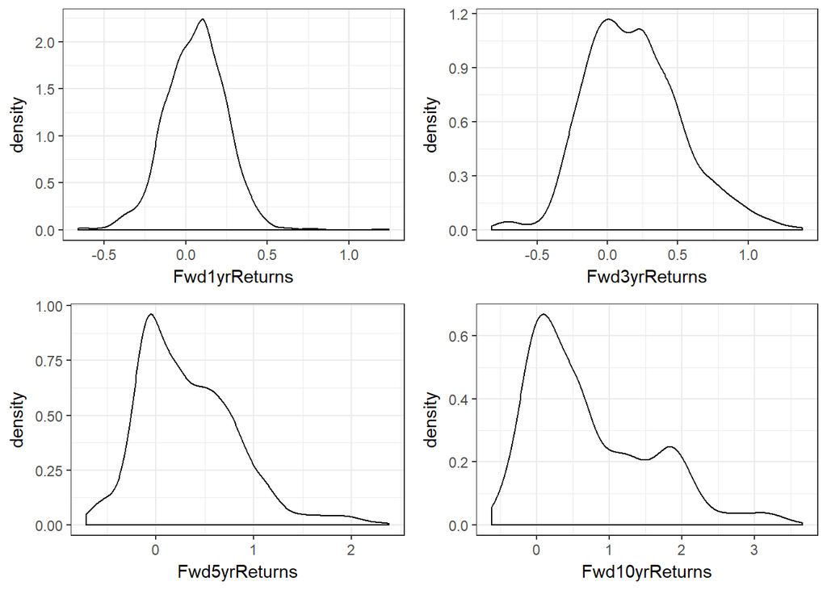

```
##  Fwd1yrReturns      Fwd3yrReturns      Fwd5yrReturns
##  Min.   :-0.65609   Min.   :-0.82409   Min.   :-0.71629
##  1st Qu.:-0.06067   1st Qu.:-0.05511   1st Qu.:-0.05574
##  Median : 0.06691   Median : 0.16223   Median : 0.24275
##  Mean   : 0.06119   Mean   : 0.18797   Mean   : 0.33082
##  3rd Qu.: 0.18493   3rd Qu.: 0.40225   3rd Qu.: 0.64044
##  Max.   : 1.24152   Max.   : 1.38523   Max.   : 2.38378
##  NA's   :12         NA's   :36         NA's   :60
##  Fwd10yrReturns
##  Min.   :-0.61661
##  1st Qu.: 0.07159
##  Median : 0.49322
##  Mean   : 0.72440
##  3rd Qu.: 1.29522
##  Max.   : 3.65442
##  NA's   :120
```

> Note that the Fwd1yReturns are the same values as momentum, but shifted 1 year.

An interesting feature of the forward returns is that they become more positively skewed the longer the duration. The skew is the affect of compounding, but there is a lower limit due to prices having never been below 0.

A logical transformation is to convert all of the returns to their compound annual growth rate (CAGR). This will also make it easier to compare them to each other.

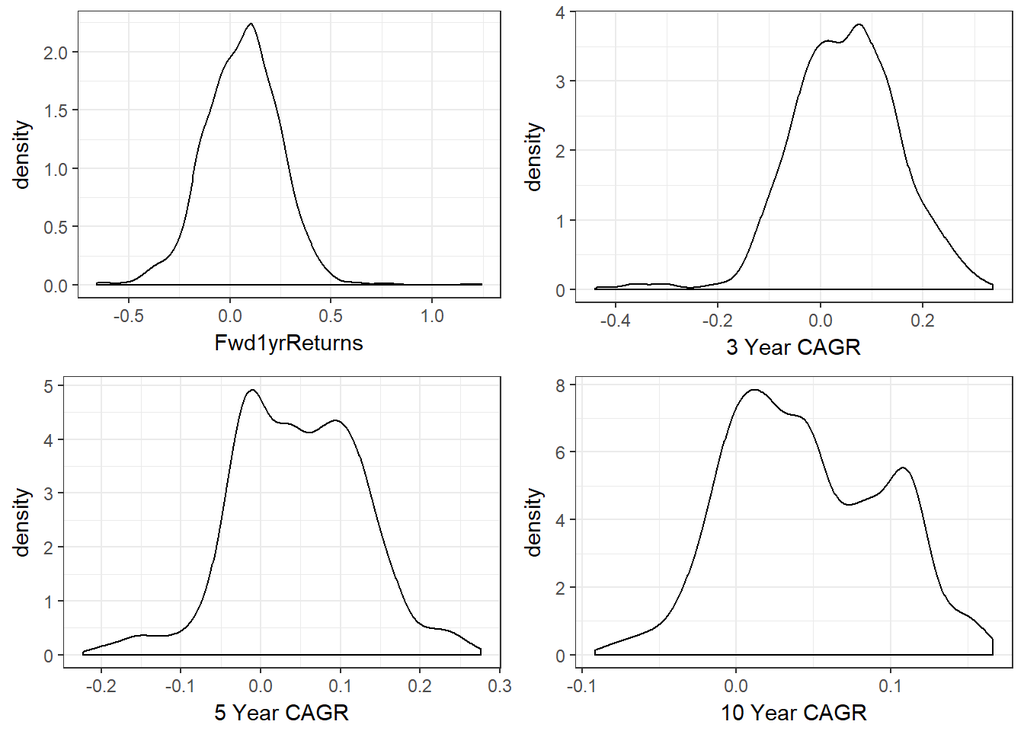

```
## [1] "1 year forward returns"
```

```
##     Min.  1st Qu.   Median     Mean  3rd Qu.     Max.     NA's
## -0.65609 -0.06067  0.06691  0.06119  0.18493  1.24152       12
```

```
## [1] "3 year forward returns"
```

```
##     Min.  1st Qu.   Median     Mean  3rd Qu.     Max.     NA's
## -0.43968 -0.01872  0.05139  0.04896  0.11929  0.33611       36
```

```
## [1] "5 year forward returns"
```

```
##     Min.  1st Qu.   Median     Mean  3rd Qu.     Max.     NA's
## -0.22273 -0.01141  0.04442  0.04690  0.10406  0.27609       60
```

```
## [1] "10 year forward returns"
```

```
##     Min.  1st Qu.   Median     Mean  3rd Qu.     Max.     NA's
## -0.09142  0.00694  0.04091  0.04517  0.08663  0.16624      120
```

The oft referred to fat tails of the returns are still present and a slight negative skew is visible. This is characteristic of the risks investors face; extreme returns occur more often than they would with a normal distribution, with greater than normal occurrence negative returns.

After seeing the transformed values I decided to store them for easier access during rest of the analysis.

# Univariate Analysis

### What is the structure of your dataset?

The dataset contains 1769 months of data covering 22 features, one of which being the date. The data covers the price, dividends and earnings for the US stock market since 1871. Also included are the Consumer Price Index (CPI) and the 10-Year Treasury rates. The first allows conversion of values from nominal to inflation adjusted levels. The Treasury rates are commonly used as a risk free benchmark.

There are also many NA values in the data because of the numerous values created from running calculations. CAPE, for example, requires 10 years of earnings values to smooth before it begins showing values.

### What is/are the main feature(s) of interest in your dataset?

Shiller’s CAPE ratio is the main feature of the dataset, allowing the analysis of market valuations over the extended time period. I also introduced momentum measures so that I can attempt to build a model for forecasting future returns.

### What other features in the dataset do you think will help support your investigation into your feature(s) of interest?

CPI is crucial in transforming the data over time to account for inflation. In addition, I expect to see that inflation itself will have affects on stock returns. I believe this will also be the case for interest rates, which are often used by governments to boost economic growth.

### Did you create any new variables from existing variables in the dataset?

A measure of momentum and inflation were created to show their running 12 month rates of change. Forward returns were also calculated and then transformed into compound annual growth rates (CAGRs) during the analysis.

Categorical values were created to allow partitioning the data into periods of Rising and Falling states of Growth and Inflation. An Outlook categorical variable was also created to test if predicting bullish and bearish periods was more feasible than predicting the specific level of return.

### Of the features you investigated, were there any unusual distributions? Did you perform any operations on the data to tidy, adjust, or change the form of the data? If so, why did you do this?

Skewed distributions are the norm in financial data, starting with the long tails in returns and carried through to prices with the effect of compounding over time. Interest rates and inflation also showed long tails.

Log transformations were applied to prices, dividends and earnings to reduce positive skew. They are also a natural transformation to apply because they convert the exponential growth of continuous compounding into an additive one. The CAPE ratio is generated from those variables and benefited from the same transformation.

I also took advantage of the inflation adjustments that were already in the data set to help visualize changes in the variables over time.

Last, I transformed the different forward return measures to annual measures to reduce skew and so that they could be directly compared.

# Bivariate Plots Section

### Stock Features

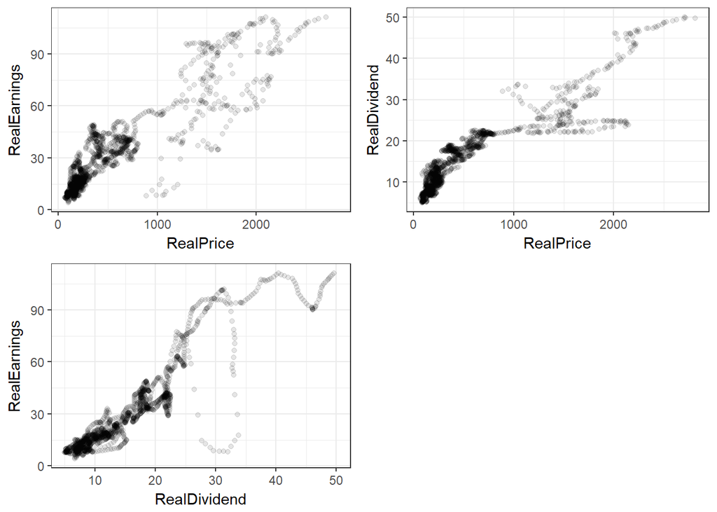

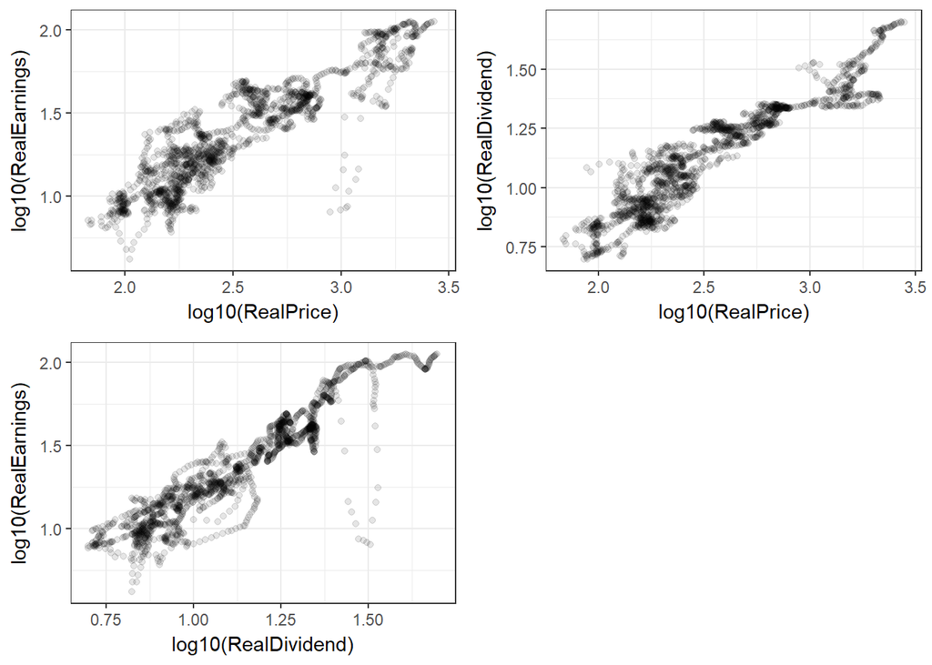

No surprises here, all of the stock features are highly correlated. Applying the log transform and transparency to reduce over plotting shows that they have strong linear relationships and have varied together over time.

### CAPE and Forward Returns

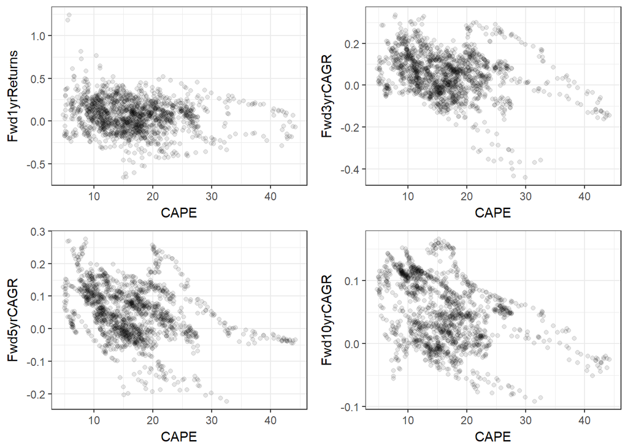

There appears to be a negative correlation to forward returns, but the effect is less prominent in the Fwd1yrReturns. It looks as though the CAPE might be less valuable in near term forecasting than for making long term predictions.

The plots also look like they could benefit from using the Log10 transformed version of CAPE.

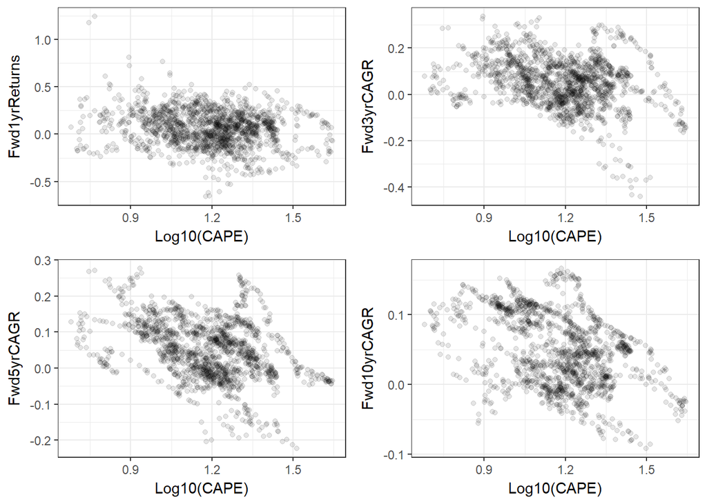

The `cor.test` function showed that he Pearson R correlations were -0.19, -0.30, -0.37 and -0.40, in order of increasing forward looking periods.

The following plots break CAPE into quintiles and show the mean returns for each quintile.

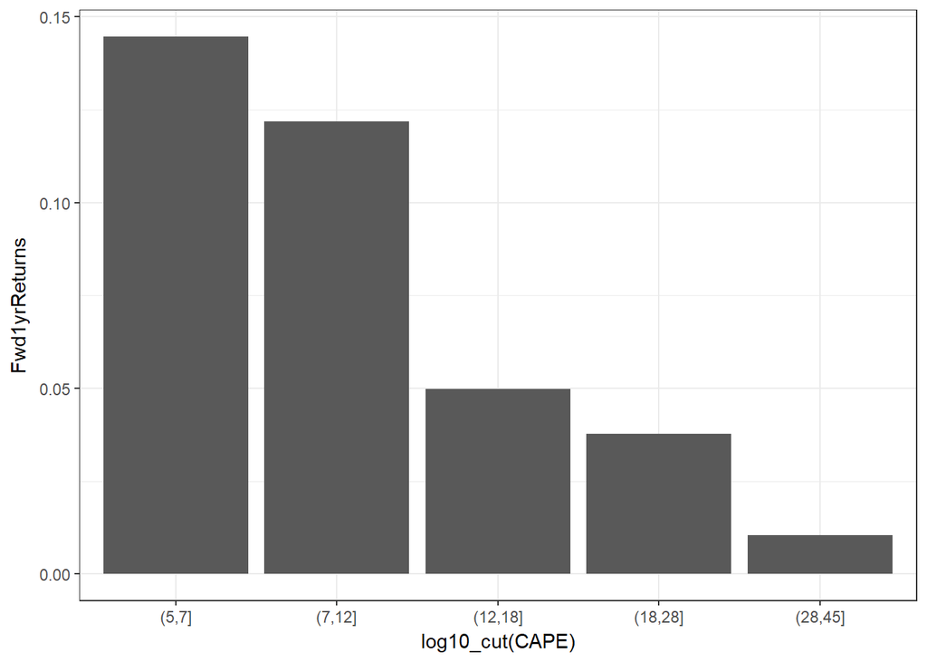

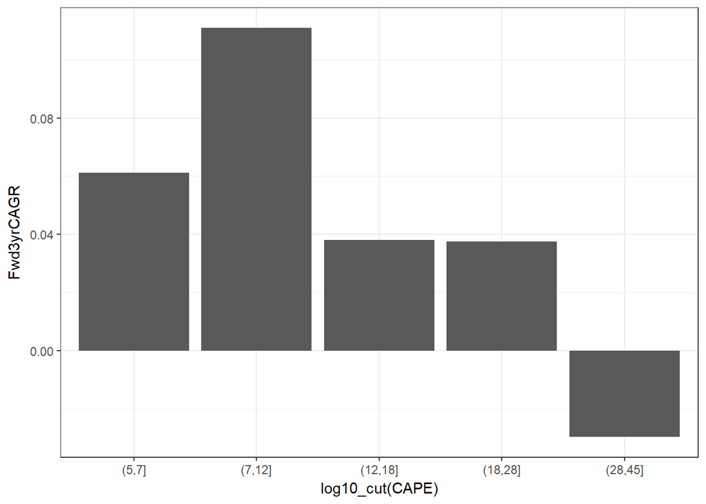

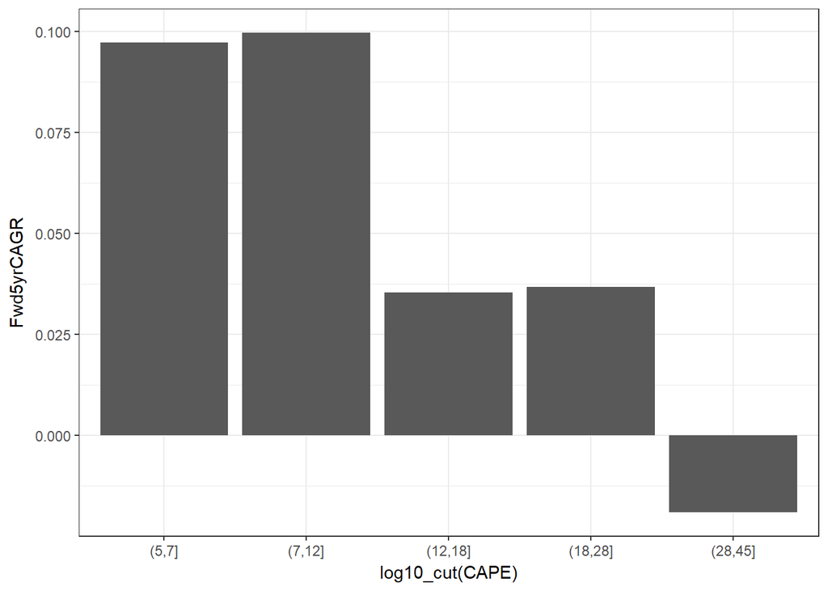

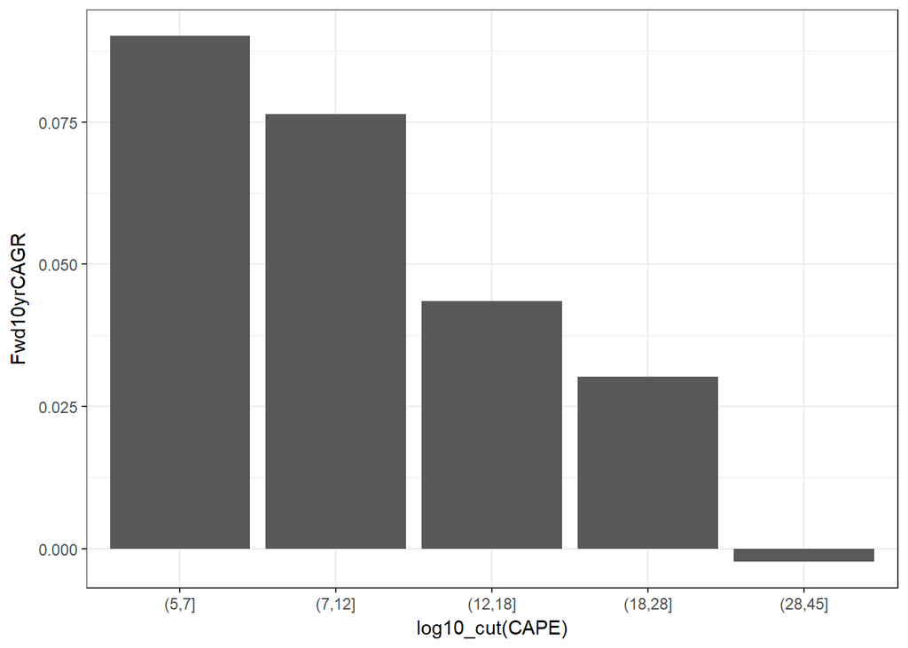

Average returns are higher starting from points when the market was selling at a discount. 1 yr returns show the highest average for the lowest CAPE reading. But the just looking at the mean does not say anything about the distribution of those returns.

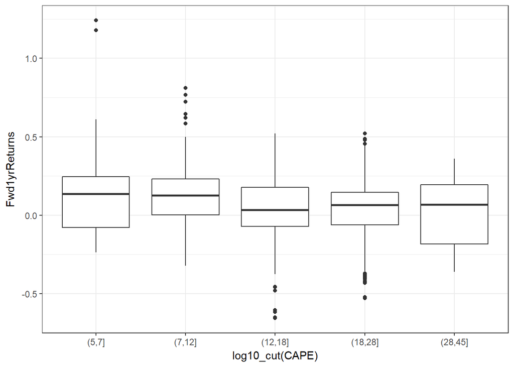

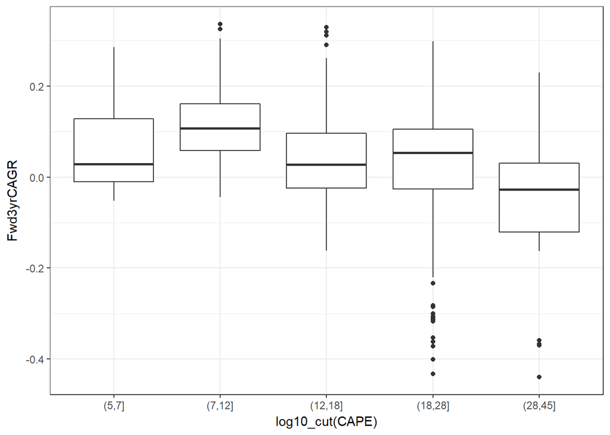

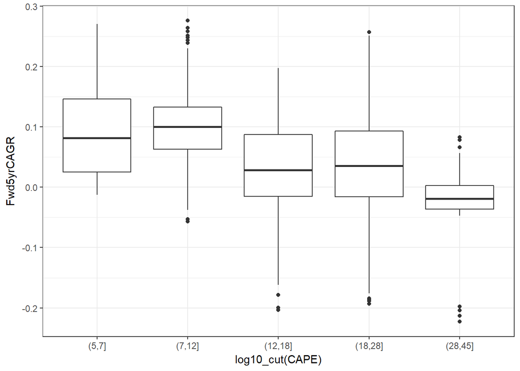

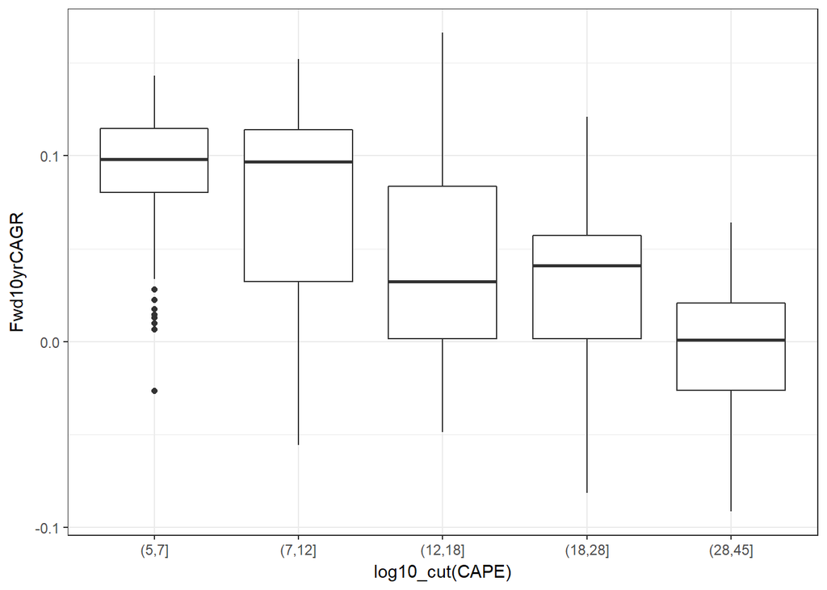

The boxplots show that the means are affected by skewed distributions. The median returns are more of an indication of what investors would earn during a typical year.

### Momentum and Forward Returns

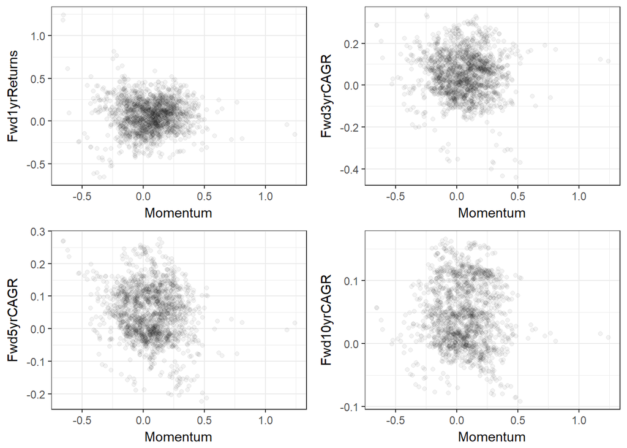

There doesn’t appear to be a strong correlation between Momentum and forward returns. It looks like there are outliers. It might help to zoom in.

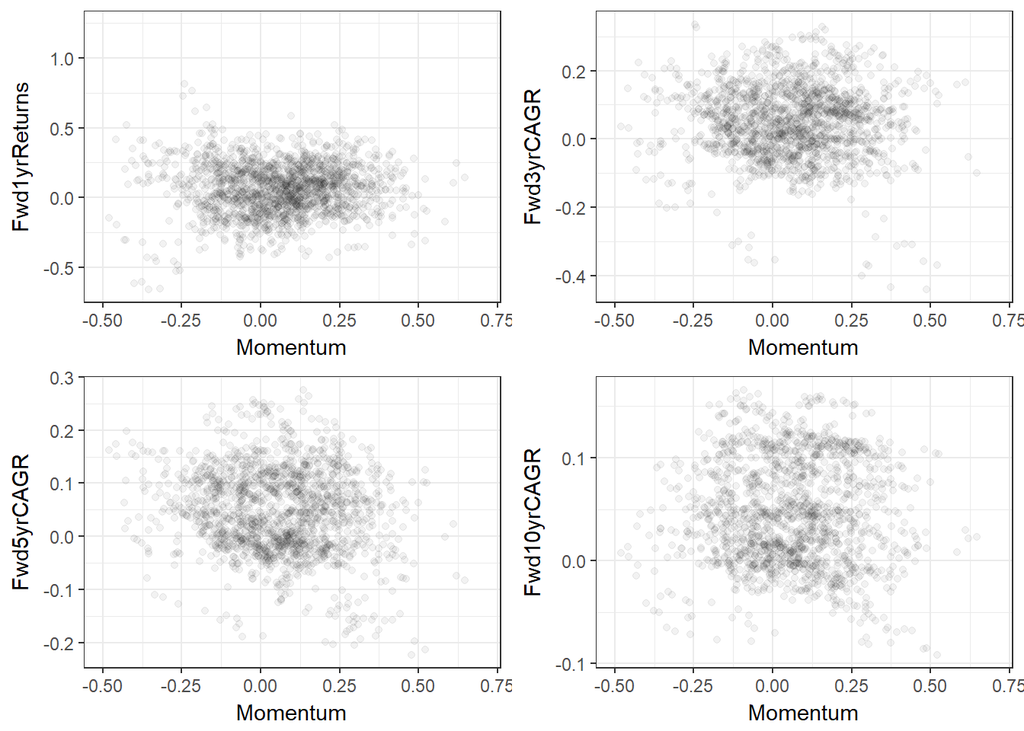

There still doesn’t appear to be a correlation, which surprises me. Momentum is the tool of choice of trend followers. Maybe the categorical Growth variable will shed some light.

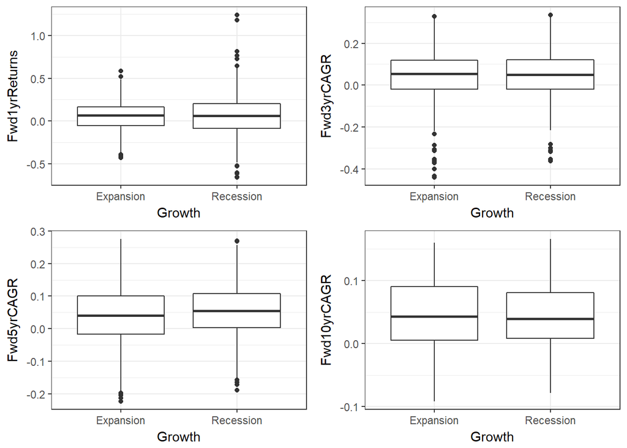

Separating the data into Rising and Falling Growth periods does not appear to provide any benefit at all in predicting higher returns. However, it does tighten the distribution and reduce the tails of the forward 1 year returns, a particular benefit in reducing risk. This is confirmation of something I have learned from studying trend following in the past: its main benefit is not in finding higher returns, but in avoiding the worst periods. However, I was expecting at least some correlation to higher future returns. If momentum were the focus of this study I would consider looking at shorter forward looking periods.

One thing to note is that this connection reverses after the first year, with the 3 and 5 year plots showing the opposite connection and lower average returns after Rising Growth readings.

### Interest Rates

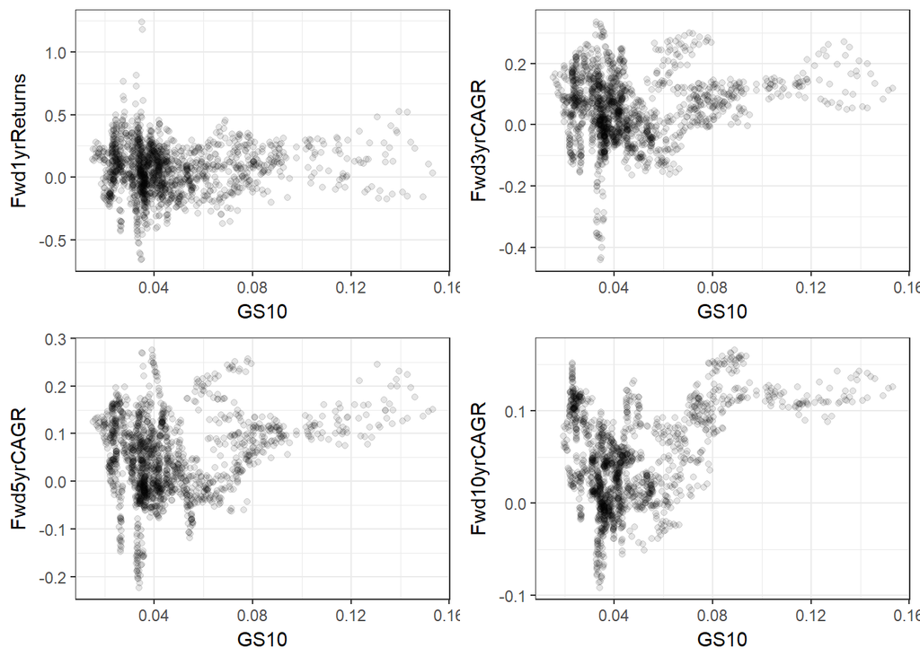

It looks like there could be correlation over longer time periods. For 1 year the Pearson R is only .05, but it increases to .14, .21 and .39 over the respective longer periods.

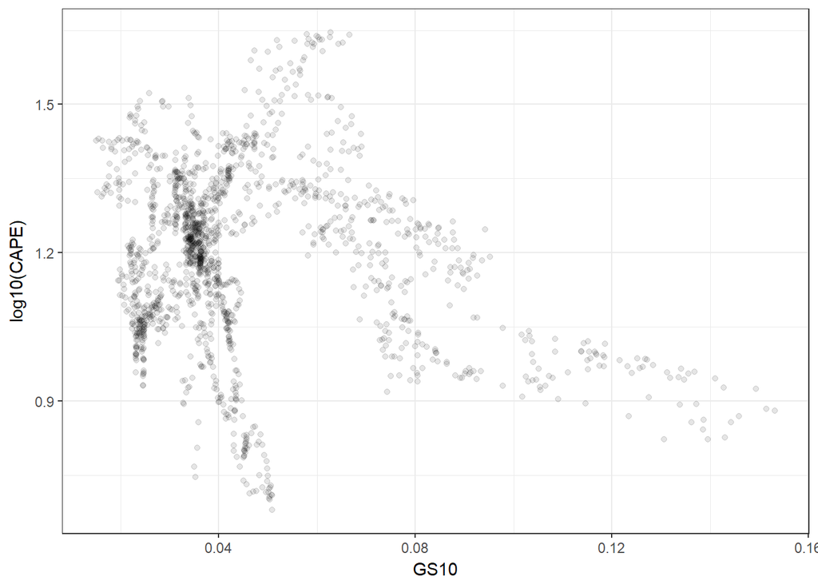

```
##
##  Pearson's product-moment correlation
##
## data:  cape$GS10 and cape$CAPE
## t = -6.4187, df = 1647, p-value = 1.793e-10
## alternative hypothesis: true correlation is not equal to 0
## 95 percent confidence interval:
##  -0.2029604 -0.1087671
## sample estimates:
##        cor
## -0.1562189
```

```
##
##  Pearson's product-moment correlation
##
## data:  cape$GS10 and log10(cape$CAPE)
## t = -9.0448, df = 1647, p-value < 2.2e-16
## alternative hypothesis: true correlation is not equal to 0
## 95 percent confidence interval:
##  -0.2630431 -0.1710574
## sample estimates:
##        cor
## -0.2175332
```

It does look like there could be some negative correlation between GS10 rates and CAPE. But the `cor.test` function returned -.16 indicating that it is very weak. The correlation is slightly stronger at -.22 when using the log10 transformed values of CAPE.